# Project A

Mitchell Toomey

January 30, 2021

### Description

This report will examine the frequencies and proportions of gun deaths in 2012 and 2019 by intent, sex, and race. First I will provide analysis of the 2012 frequency counts, proportions and bar plots of gun deaths by intent, sex, and race. Then, I will outline analyses of the 2019 frequency counts, proportions and bar plots of gun deaths by intent, sex, and race. I will conclude this report with comparing percent of gun deaths between 2012 and 2019 by intent, sex, and race.

*Source of data: The “Gun Deaths in America” data from the CDC’s Multiple Cause of Death Database,* *which is derived from death certificates from all 50 states and the District of Columbia and is widely considered the most comprehensive estimate of firearm deaths.*

### Analysis of gun deaths in 2012

In this data set, gun death intent is divided into four categories: suicide, homicide, accidental, and undetermined. Race is dived into five categories: White, Black, Hispanic, Native American/Native Alaskan, Asian/Pacific Islander Gender is categorized as either male or female.

Figure 1 shows the proportion of gun deaths in 2012 by intent. According to the table, gun deaths by suicide were the highest proportion, followed by homicide. Accidental and undetermined gun deaths made up between 2-3 % of gun deaths in 2012.

*Figure 1. Bar plots with proportion of gun death intent*

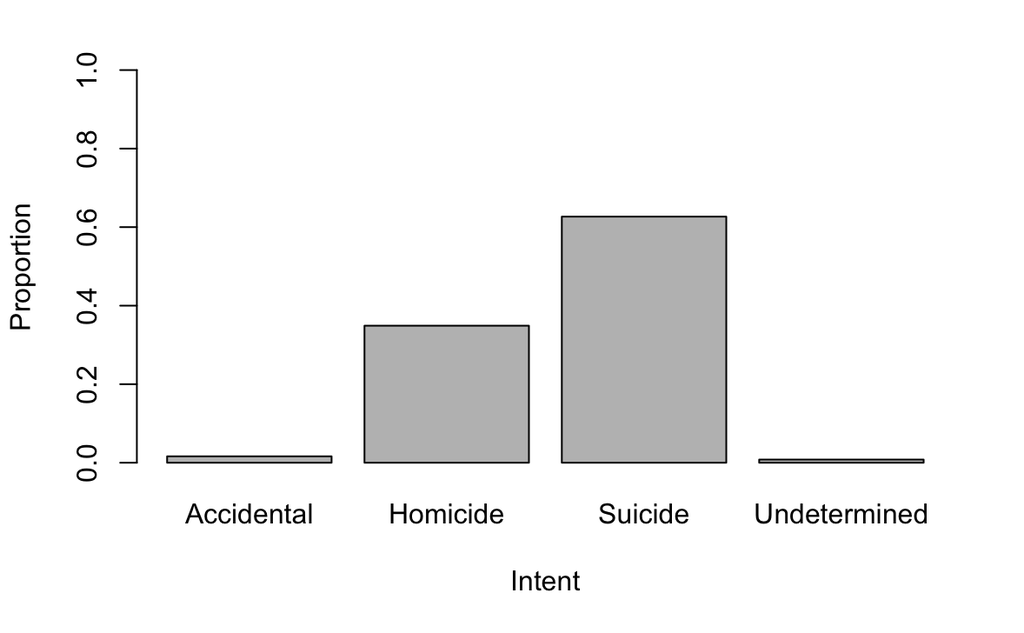

Table 1 shows in numeric form that homicide and suicide made up the largest proportions of gun deaths in 2012 at roughly 97%.

*Table 1. Frequencies and proportions of gun deaths by intent.*

```
             intent.counts_12 intent.props_12
Accidental               1639     0.016260405
Homicide                35176     0.348978640
Suicide                 63175     0.626754765
Undetermined              807     0.008006191
```

Figure 2 shows that males had higher rates of gun deaths in 2012 than females.

*Figure 2. Bar plots with proportion gun deaths by sex*

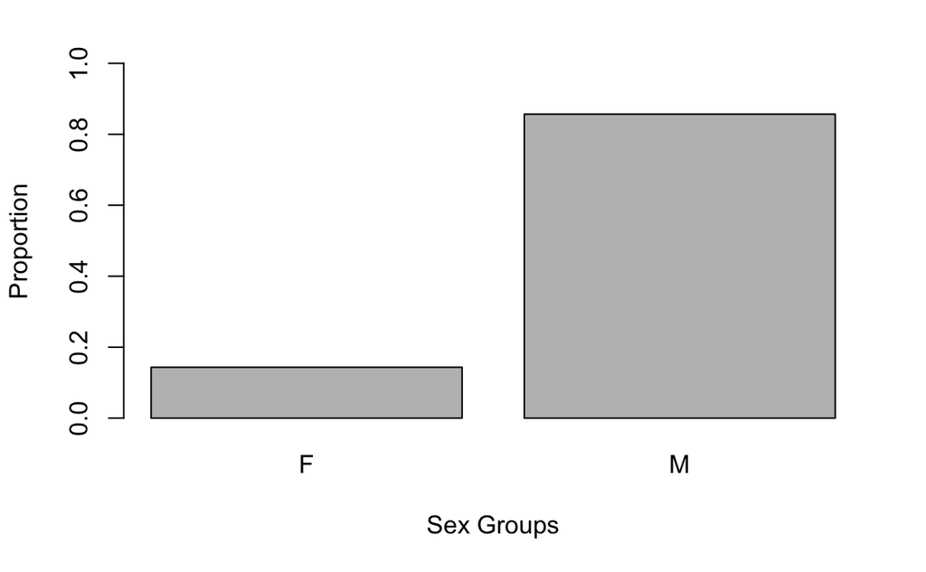

Table 2 provides the numeric forms of the data presented in figure 2, showing that males comprised roughly 86% of gun deaths in 2012.

*Table 2. Frequencies and proportions of gun deaths by sex*

```
  sex.counts_12 sex.props_12
F         14449    0.1433461
M         86349    0.8566539
```

According to figure 3, White individuals comprised the highest proportion of gun deaths in 2012, followed by Black individuals, then Hispanic individuals, Asian Pacific Islander individuals, and native individuals.

*Figure 3. Bar plots with proportion of gun deaths by race*

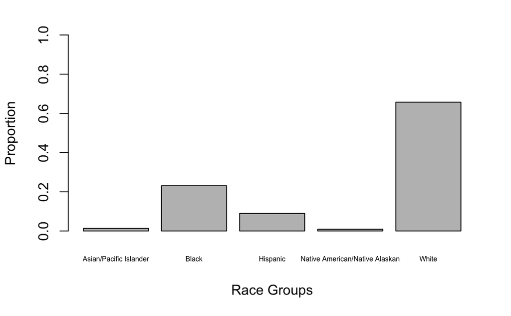

Table 3 numerically represents the results in Figure 3, and shows that White and Black individuals made up roughly 88% of gun deaths in 2012. Hispanic individuals comprised about 9% of gun deaths in 2012, followed by Asian/Pacific Islander individuals (1.3%) and Native individuals (1%).

*Table 3. Frequencies and proportions of gun deaths by race*

```
                               race.counts_12 race.props_12
Asian/Pacific Islander                   1326   0.013155023
Black                                   23296   0.231115697
Hispanic                                 9022   0.089505744
Native American/Native Alaskan            917   0.009097403
White                                   66237   0.657126133
```

### Analysis of gun deaths in 2019

In this data set, gun death intent is divided into four categories: suicide, homicide, accidental, and undetermined. Race is dived into five categories: White, Black, Hispanic, Native American/Native Alaskan, Asian/Pacific Islander Gender is categorized as either male or female.

Figure 4 shows that in 2019, the number of gun deaths were comprised mostly of suicides, followed by homicides. Accidental and undetermined deaths made up a very small proportion of gun deaths in 2019.

*Figure 4. Bar plots with proportion of gun death intent in 2019*

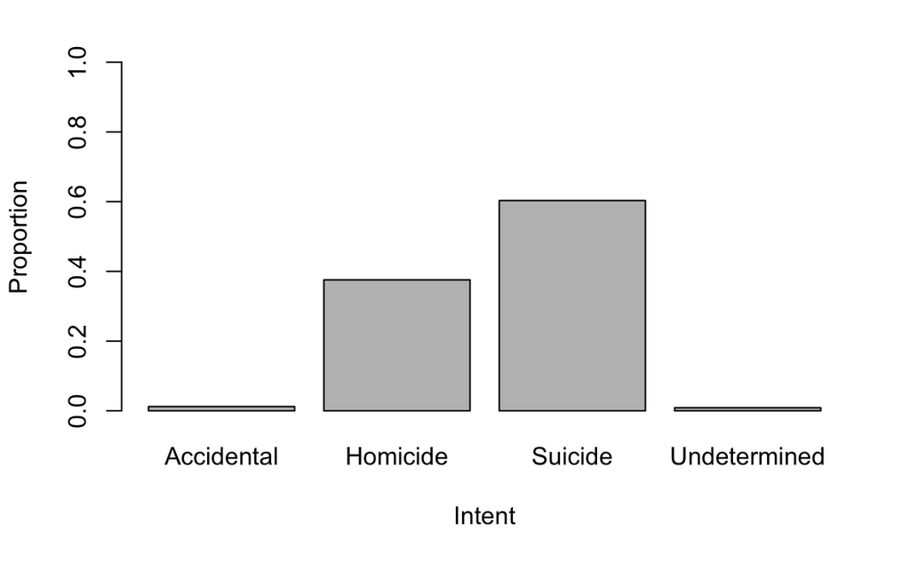

*Table 4. Frequencies and proportions of gun deaths in 2019 by intent*

```
             intent.counts_19 intent.props_19
Accidental                486     0.012247367
Homicide                14909     0.375711910
Suicide                 23941     0.603321405
Undetermined              346     0.008719319
```

Figure 5 shows that in 2019, males comprised a higher proportion of gun deaths than females.

*Figure 5. Bar plots with proportion gun deaths by sex in 2019*

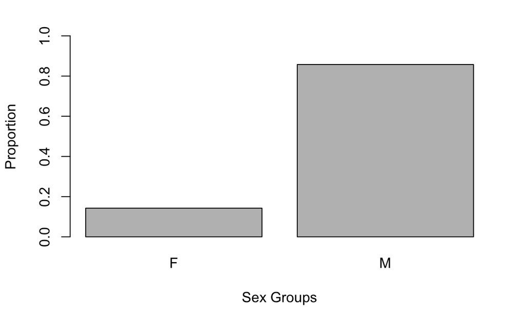

Table 5 shows numerically that males made up 86% of gun deaths and and females made up 14% of gun deaths in 2019.

*Table 5. Frequencies and proportions of gun deaths in 2019 by sex*

```
  sex.counts_19 sex.props_19
F          5666    0.1426952
M         34041    0.8573048
```

Figure 6 shows the highest proportions of gun deaths in 2019 were among White individuals, followed by Black individuals, then Hispanic individuals, Asian/Pacific Islander individuals, and Native individuals.

*Figure 6. Bar plots with proportion of gun deaths by race in 2019*

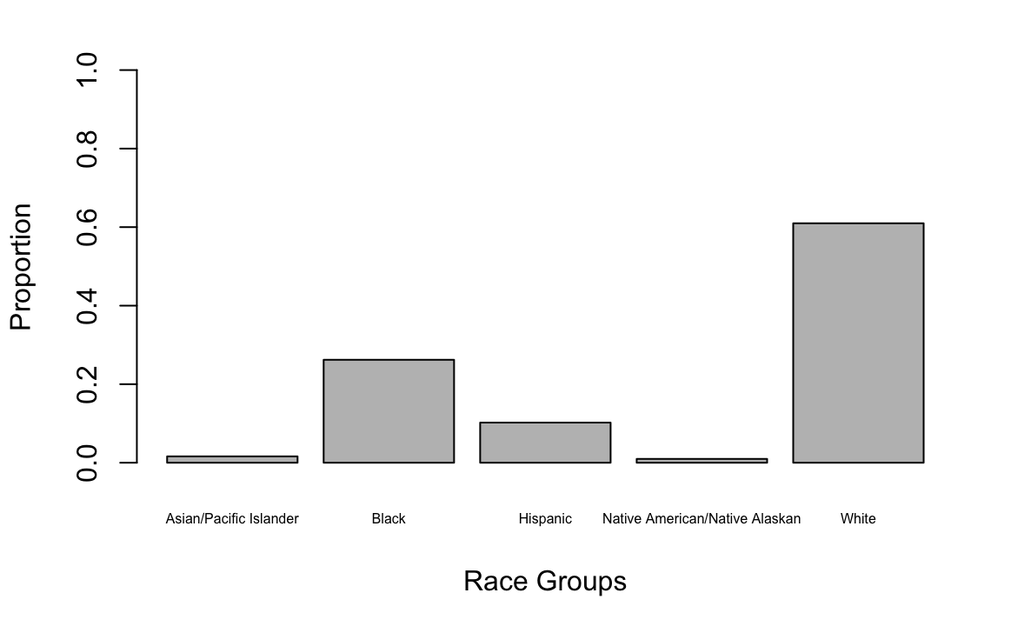

Table 6 numerically shows that White individuals comprised 61% of gun deaths in 2019, followed by Black individuals (26%), Hispanic individuals (10%), Asian/Pacific Islander individuals (2%), and Native individuals (1%).

*Table 6. Frequencies and proportions of gun deaths in 2019 by race*

```
                               race.counts_19 race.props_19
Asian/Pacific Islander                    641   0.016143249
Black                                   10410   0.262170398
Hispanic                                 4058   0.102198605
Native American/Native Alaskan            386   0.009721208
White                                   24212   0.609766540
```

### Analyses comparing gun deaths between 2012 and 2019

Figure 7 shows that the proportions of gun deaths by intent were mostly similar between 2012 and 2019, with suicide being the highest intent, and homicide following.

*Figure 7. Comparing intent behind gun deaths between years 2012 and 2019.*

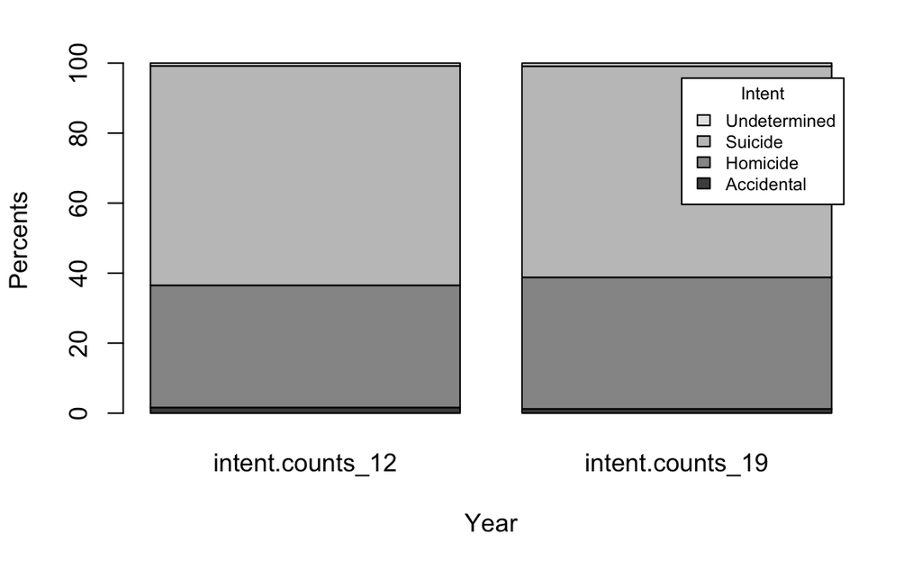

```
             intent.counts_12 intent.counts_19 intent.counts_12
Accidental               1639              486        1.6260405
Homicide                35176            14909       34.8978640
Suicide                 63175            23941       62.6754765
Undetermined              807              346        0.8006191
             intent.counts_19
Accidental          1.2247367
Homicide           37.5711910
Suicide            60.3321405
Undetermined        0.8719319
```

Figure 8 shows that proportions of gun deaths between males and females were very similar between 2012 and 2019, with males making up the majority of gun deaths in both years than females.

*Figure 8. Comparing gun deaths by sex between years 2012 and 2019.*

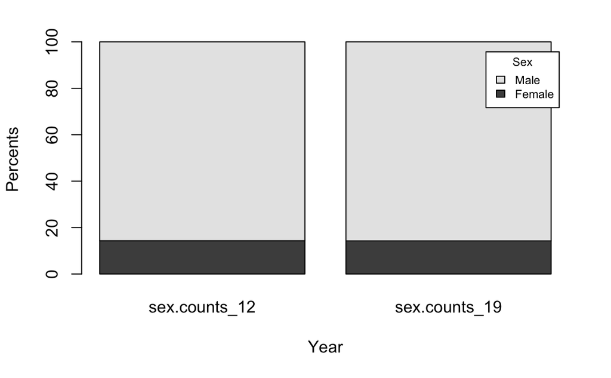

```
  sex.counts_12 sex.counts_19 sex.counts_12 sex.counts_19
F         14449          5666      14.33461      14.26952
M         86349         34041      85.66539      85.73048
```

According to figure 9, the the proportions of gun deaths between 2012 and 2019 were similar across racial groups. In both years, White individuals made up the majority of gun deaths, followed by Black individuals, then Hispanic individuals, Asian/Pacific Islander individuals, and Native individuals.

*Figure 9. Comparing gun deaths by race between years 2012 and 2019.*

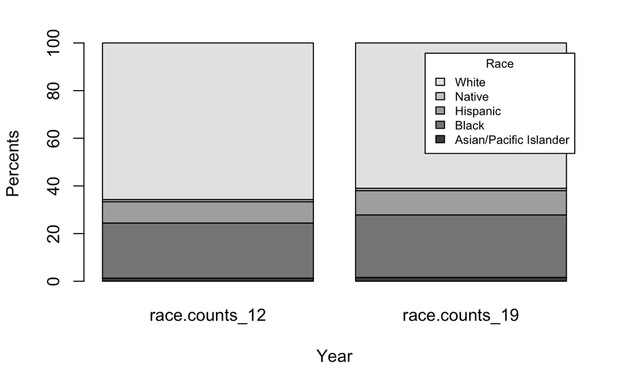

```
                               race.counts_12 race.counts_19 race.counts_12
Asian/Pacific Islander                   1326            641      1.3155023
Black                                   23296          10410     23.1115697
Hispanic                                 9022           4058      8.9505744
Native American/Native Alaskan            917            386      0.9097403
White                                   66237          24212     65.7126133
                               race.counts_19
Asian/Pacific Islander              1.6143249
Black                              26.2170398
Hispanic                           10.2198605
Native American/Native Alaskan      0.9721208
White                              60.9766540
```

### Conclusions

I examined the frequencies and proportions of gun deaths in 2012 and 2019 based on intent of death, sex, and race. Ultimately, the trends in the data were similar between 2012 and 2019. Regarding intent, suicides comprised the highest number of gun deaths across both years, with homicides being the the second most cause of gun deaths, cumulatively comprising over 90% of gun deaths across both years. Gun deaths were also comparable across gender and race. Males had higher rates of gun deaths than females across both years. Additionally, across both years, the proportions of White individuals who died from gun deaths was the highest among any other racial group, with Black individuals being the second highest proportion. Overall, the consistency in trends in the data across both years indicate some common trends of the intent behind gun deaths in America, as well as who dies more as a result of gun deaths.